# CMSC320: Introduction to Data Science - Final Tutorial - Analysis of Movie Dataset: Exploring Factors Affecting Movie Success and Predictive Modeling

## Introduction

The world of movies has always captivated audiences, offering a glimpse into different worlds, emotions, and stories. With the advent of digital platforms and advancements in technology, the movie industry has experienced significant growth, leading to an explosion of movies being produced and consumed globally. Amidst this vast landscape of films, understanding the factors that contribute to a movie's success or failure becomes crucial for filmmakers, producers, and investors alike.

This tutorial aims to explore and analyze the IMDb movies database, a comprehensive collection of movie-related information, to gain insights into the various aspects that influence a movie's performance. By delving into this dataset, we seek to uncover patterns, trends, and relationships that can shed light on the factors behind a movie's success, such as ratings, genres, budgets, and more.

My personal interest in this analysis stems from my fascination with the magic of movies and the desire to unravel the underlying dynamics that shape their outcomes. By leveraging data science techniques, I will extract valuable information from this extensive movie database. This will enabling us to make informed decisions and predictions in the realm of filmmaking and entertainment.

The importance of this problem in the data science industry cannot be understated. The movie industry is highly competitive, with filmmakers and production companies constantly striving to create films that resonate with audiences and generate substantial returns on investment. By leveraging data-driven insights, industry professionals can make informed decisions about which genres to explore, how to allocate budgets effectively, and which elements to prioritize in their productions. Additionally, understanding the preferences and expectations of moviegoers can contribute to the creation of more engaging and captivating films.

## Data Collection

During this project, we will be using Python language, and we use tools such as iPython and Jupiter Notebook to develop this project. If you haven't heard about Jupiter notebooks before, make sure to learn more about them in [here](https://ipython.org/).

The following libraries/tools will be used throughout the project. If you do not have any of these libraries installed, you can install them into your development environmemt with the help of $ pip3 install. I will be using Python 3 and the following standard libraries:

1. [Numpy](https://docs.scipy.org/doc/numpy-1.13.0/index.html): Numerical computing library
2. [Pandas](https://pandas.pydata.org/pandas-docs/stable/index.html): Data manipulation library.
3. [Scikit-Learn](https://scikit-learn.org/stable/): Machine learning library.
4. [Seaborn](https://seaborn.pydata.org/): Statistical data visualization library.
5. [Plotly](https://plotly.com/python/) - creating the map of New York City
6. [Matplotlib](https://matplotlib.org/stable/index.html): Data visualization library.
7. [Statsmodels](https://www.statsmodels.org/stable/index.html): Statistical modeling library.
8. [Support Vector Classifier](https://scikit-learn.org/stable/modules/generated/sklearn.svm.SVC.html) (SVC) (from sklearn): Support vector classifier algorithm implementation.
9. [Random Forest Classifier](https://scikit-learn.org/stable/modules/generated/sklearn.ensemble.RandomForestClassifier.html) (from sklearn): Random forest classifier algorithm implementation.

```python
#Importing relevat libraries
import pandas as pd
import numpy as np
import matplotlib.pyplot as plt
import seaborn as sns

import statsmodels.api as sm
from statsmodels.stats.proportion import proportions_ztest
from sklearn import linear_model

import statsmodels.api as sm


from sklearn.impute import SimpleImputer
from sklearn.svm import SVC
from sklearn.ensemble import RandomForestClassifier
from sklearn import metrics
```

To start this tuturial, lets see what the dataset looks like. The dataset is stored as a .csv file.

```python
# Load the data from the downloaded CSV file
df = pd.read_csv('//content/drive/MyDrive/Final Tutorial/movie_metadata.csv')

# Print the first few rows of the data
df.head()
```

|  | color | director_name | num_critic_for_reviews | duration | director_facebook_likes | actor_3_facebook_likes | actor_2_name | actor_1_facebook_likes | gross | genres | ... | num_user_for_reviews | language | country | content_rating | budget | title_year | actor_2_facebook_likes | imdb_score | aspect_ratio | movie_facebook_likes |
| --- | --- | --- | --- | --- | --- | --- | --- | --- | --- | --- | --- | --- | --- | --- | --- | --- | --- | --- | --- | --- | --- |
| 0 | Color | James Cameron | 723.0 | 178.0 | 0.0 | 855.0 | Joel David Moore | 1000.0 | 760505847.0 | Action\|Adventure\|Fantasy\|Sci-Fi | ... | 3054.0 | English | USA | PG-13 | 237000000.0 | 2009.0 | 936.0 | 7.9 | 1.78 | 33000 |
| 1 | Color | Gore Verbinski | 302.0 | 169.0 | 563.0 | 1000.0 | Orlando Bloom | 40000.0 | 309404152.0 | Action\|Adventure\|Fantasy | ... | 1238.0 | English | USA | PG-13 | 300000000.0 | 2007.0 | 5000.0 | 7.1 | 2.35 | 0 |
| 2 | Color | Sam Mendes | 602.0 | 148.0 | 0.0 | 161.0 | Rory Kinnear | 11000.0 | 200074175.0 | Action\|Adventure\|Thriller | ... | 994.0 | English | UK | PG-13 | 245000000.0 | 2015.0 | 393.0 | 6.8 | 2.35 | 85000 |
| 3 | Color | Christopher Nolan | 813.0 | 164.0 | 22000.0 | 23000.0 | Christian Bale | 27000.0 | 448130642.0 | Action\|Thriller | ... | 2701.0 | English | USA | PG-13 | 250000000.0 | 2012.0 | 23000.0 | 8.5 | 2.35 | 164000 |
| 4 | NaN | Doug Walker | NaN | NaN | 131.0 | NaN | Rob Walker | 131.0 | NaN | Documentary | ... | NaN | NaN | NaN | NaN | NaN | NaN | 12.0 | 7.1 | NaN | 0 |

5 rows × 28 columns

## Coulumn heading and their description -

- **color**: Indicates whether the movie is in color or black and white.
- **director_name**: The name of the director of the movie.
- **num_critic_for_reviews**: The number of critic reviews for the movie.
- **duration**: The duration of the movie in minutes.
- **director_facebook_likes**: The number of Facebook likes for the director.
- **actor_3_facebook_likes**: The number of Facebook likes for the third actor in the movie.
- **actor_2_name**: The name of the second actor in the movie.
- **actor_1_facebook_likes**: The number of Facebook likes for the first actor in the movie.
- **gross**: The gross earnings of the movie.
- **genres**: The genres of the movie (e.g., action, drama, comedy).
- **actor_1_name**: The name of the first actor in the movie.
- **movie_title**: The title of the movie.
- **num_voted_users**: The number of users who voted for the movie on IMDB.
- **cast_total_facebook_likes**: The total number of Facebook likes for all actors in the movie.
- **actor_3_name**: The name of the third actor in the movie.
- **facenumber_in_poster**: The number of faces visible on the movie poster.
- **plot_keywords**: Keywords associated with the movie's plot.
- **movie_imdb_link**: The IMDB link for the movie.
- **num_user_for_reviews**: The number of user reviews for the movie.
- **language**: The language of the movie.
- **country**: The country where the movie was produced.
- **content_rating**: The content rating of the movie (e.g., PG-13, R, G).
- **budget**: The budget of the movie.
- **title_year**: The year when the movie was released.
- **actor_2_facebook_likes**: The number of Facebook likes for the second actor in the movie.
- **imdb_score**: The IMDB rating score for the movie.
- **aspect_ratio**: The aspect ratio of the movie.
- **movie_facebook_likes**: The number of Facebook likes for the movie's Facebook page.

This dataset contains 28 variables for 5043 movies spanning across 100 years in 66 countries. There are 2399 unique director names, and thousands of actors/actresses.

## Data Tidying

Let us first check how many null or missing values we have in our dataset

```python
#Printing the sum of the null values
df.isna().sum()
```

```
color                         19
director_name                104
num_critic_for_reviews        50
duration                      15
director_facebook_likes      104
actor_3_facebook_likes        23
actor_2_name                  13
actor_1_facebook_likes         7
gross                        884
genres                         0
actor_1_name                   7
movie_title                    0
num_voted_users                0
cast_total_facebook_likes      0
actor_3_name                  23
facenumber_in_poster          13
plot_keywords                153
movie_imdb_link                0
num_user_for_reviews          21
language                      12
country                        5
content_rating               303
budget                       492
title_year                   108
actor_2_facebook_likes        13
imdb_score                     0
aspect_ratio                 329
movie_facebook_likes           0
dtype: int64
```

We can remove the null values from the dataset where the null value count is less. So that we don't loose much data

```python
#Dropping the unecessary columns
df.dropna(axis=0,subset=['director_name', 'num_critic_for_reviews','duration','director_facebook_likes','actor_3_facebook_likes',
                         'actor_2_name','actor_1_facebook_likes','actor_1_name','actor_3_name','facenumber_in_poster',
                         'num_user_for_reviews','language','country','actor_2_facebook_likes','plot_keywords'],inplace=True)
df.isna().sum()
```

```
color                          8
director_name                  0
num_critic_for_reviews         0
duration                       0
director_facebook_likes        0
actor_3_facebook_likes         0
actor_2_name                   0
actor_1_facebook_likes         0
gross                        644
genres                         0
actor_1_name                   0
movie_title                    0
num_voted_users                0
cast_total_facebook_likes      0
actor_3_name                   0
facenumber_in_poster           0
plot_keywords                  0
movie_imdb_link                0
num_user_for_reviews           0
language                       0
country                        0
content_rating               169
budget                       352
title_year                     0
actor_2_facebook_likes         0
imdb_score                     0
aspect_ratio                 209
movie_facebook_likes           0
dtype: int64
```

We can .shape() method to get the dimensions of the dataset

```python
df.shape
```

```
(4737, 28)
```

We lost only 6% of the data which is acceptable

Lets rename the column to make the data more readable

```python
#Rename the columns to make the data readable
df = df.rename(columns = {'director_name':'Director', 'actor_2_name':'Actor_2', 'gross':'Gross', 'genres':'Genres', 'actor_1_name':'Actor_1',
                        'movie_title':'Movie_title', 'actor_3_name':'Actor_3', 'language':'Language', 'country':'Country',
                        'content_rating':'Content_Rating', 'budget':'Budget', 'title_year':'Year', 'imdb_score':'IMDB_Score',
                        'movie_facebook_likes':'Facebook_Likes'}, inplace=False)
df.head()
```

|  | color | Director | num_critic_for_reviews | duration | director_facebook_likes | actor_3_facebook_likes | Actor_2 | actor_1_facebook_likes | Gross | Genres | ... | num_user_for_reviews | Language | Country | Content_Rating | Budget | Year | actor_2_facebook_likes | IMDB_Score | aspect_ratio | Facebook_Likes |
| --- | --- | --- | --- | --- | --- | --- | --- | --- | --- | --- | --- | --- | --- | --- | --- | --- | --- | --- | --- | --- | --- |
| 0 | Color | James Cameron | 723.0 | 178.0 | 0.0 | 855.0 | Joel David Moore | 1000.0 | 760505847.0 | Action\|Adventure\|Fantasy\|Sci-Fi | ... | 3054.0 | English | USA | PG-13 | 237000000.0 | 2009.0 | 936.0 | 7.9 | 1.78 | 33000 |
| 1 | Color | Gore Verbinski | 302.0 | 169.0 | 563.0 | 1000.0 | Orlando Bloom | 40000.0 | 309404152.0 | Action\|Adventure\|Fantasy | ... | 1238.0 | English | USA | PG-13 | 300000000.0 | 2007.0 | 5000.0 | 7.1 | 2.35 | 0 |
| 2 | Color | Sam Mendes | 602.0 | 148.0 | 0.0 | 161.0 | Rory Kinnear | 11000.0 | 200074175.0 | Action\|Adventure\|Thriller | ... | 994.0 | English | UK | PG-13 | 245000000.0 | 2015.0 | 393.0 | 6.8 | 2.35 | 85000 |
| 3 | Color | Christopher Nolan | 813.0 | 164.0 | 22000.0 | 23000.0 | Christian Bale | 27000.0 | 448130642.0 | Action\|Thriller | ... | 2701.0 | English | USA | PG-13 | 250000000.0 | 2012.0 | 23000.0 | 8.5 | 2.35 | 164000 |
| 5 | Color | Andrew Stanton | 462.0 | 132.0 | 475.0 | 530.0 | Samantha Morton | 640.0 | 73058679.0 | Action\|Adventure\|Sci-Fi | ... | 738.0 | English | USA | PG-13 | 263700000.0 | 2012.0 | 632.0 | 6.6 | 2.35 | 24000 |

5 rows × 28 columns

Next I am replacing missing values in Content_Rating with the value 'R'and the missing values for Budget and Gross with their medians so there is no further loss of data.

```python
#Replacing the content rating with Value R as it has highest frequency
df["Content_Rating"].fillna("R", inplace = True)

#We need to replace the value in budget with the median of the value
df["Budget"].fillna(df["Budget"].median(),inplace=True)


# We need to replace the value in gross with the median of the value
df["Gross"].fillna(df["Gross"].median(),inplace=True)


#Replacing the aspect_ratio with the median of the value as the graph is right skewed
df["aspect_ratio"].fillna(df["aspect_ratio"].median(),inplace=True)


df.isna().sum()
```

```
color                        8
Director                     0
num_critic_for_reviews       0
duration                     0
director_facebook_likes      0
actor_3_facebook_likes       0
Actor_2                      0
actor_1_facebook_likes       0
Gross                        0
Genres                       0
Actor_1                      0
Movie_title                  0
num_voted_users              0
cast_total_facebook_likes    0
Actor_3                      0
facenumber_in_poster         0
plot_keywords                0
movie_imdb_link              0
num_user_for_reviews         0
Language                     0
Country                      0
Content_Rating               0
Budget                       0
Year                         0
actor_2_facebook_likes       0
IMDB_Score                   0
aspect_ratio                 0
Facebook_Likes               0
dtype: int64
```

We need to aslo check the data type of each column. Lets go ahead and print the info for the dataset.

```python
#Printing dataset info
df.info()
```

```
<class 'pandas.core.frame.DataFrame'>
Int64Index: 4737 entries, 0 to 5042
Data columns (total 28 columns):
 #   Column                     Non-Null Count  Dtype
---  ------                     --------------  -----
 0   color                      4729 non-null   object
 1   Director                   4737 non-null   object
 2   num_critic_for_reviews     4737 non-null   float64
 3   duration                   4737 non-null   float64
 4   director_facebook_likes    4737 non-null   float64
 5   actor_3_facebook_likes     4737 non-null   float64
 6   Actor_2                    4737 non-null   object
 7   actor_1_facebook_likes     4737 non-null   float64
 8   Gross                      4737 non-null   float64
 9   Genres                     4737 non-null   object
```

[output cut: 20 more lines]

As we can see that yeear is type float so we need to convert it into an integer type

```python
# Change year to type int
df['Year'] = df['Year'].astype(int)
```

When we look at the data table, there are several columns that seem to be unnecessary to our data exploration such as color, plot keywords, cast like on FaceBookpage, aspect ratio, etc. In this case, we drop these columns since we do not need them for our analysis.

```python
# Removing unnecessary columns
columns_to_drop = ['color', 'director_facebook_likes', 'actor_3_facebook_likes', 'actor_1_facebook_likes',
                   'num_voted_users', 'aspect_ratio', 'plot_keywords', 'num_critic_for_reviews',
                   'num_user_for_reviews', 'num_critic_for_reviews', 'duration', 'facenumber_in_poster', 'movie_imdb_link',
                   'actor_2_facebook_likes','cast_total_facebook_likes','facenumber_in_poster', 'Actor_1', 'Actor_2', 'Actor_3']
data = df.drop(columns_to_drop, axis=1)

# Print the modified DataFrame
data.head()
```

|  | Director | Gross | Genres | Movie_title | Language | Country | Content_Rating | Budget | Year | IMDB_Score | Facebook_Likes |
| --- | --- | --- | --- | --- | --- | --- | --- | --- | --- | --- | --- |
| 0 | James Cameron | 760505847.0 | Action\|Adventure\|Fantasy\|Sci-Fi | Avatar | English | USA | PG-13 | 237000000.0 | 2009 | 7.9 | 33000 |
| 1 | Gore Verbinski | 309404152.0 | Action\|Adventure\|Fantasy | Pirates of the Caribbean: At World's End | English | USA | PG-13 | 300000000.0 | 2007 | 7.1 | 0 |
| 2 | Sam Mendes | 200074175.0 | Action\|Adventure\|Thriller | Spectre | English | UK | PG-13 | 245000000.0 | 2015 | 6.8 | 85000 |
| 3 | Christopher Nolan | 448130642.0 | Action\|Thriller | The Dark Knight Rises | English | USA | PG-13 | 250000000.0 | 2012 | 8.5 | 164000 |
| 5 | Andrew Stanton | 73058679.0 | Action\|Adventure\|Sci-Fi | John Carter | English | USA | PG-13 | 263700000.0 | 2012 | 6.6 | 24000 |

One movie can have multiple genres. So, each record of genres is combined with a few types, which will cause diculty in analyzing. I will go ahead and spilt the generes.

```python
# Create logical attributes for each genre
data['Action'] = data['Genres'].str.contains('Action')
data['Adventure'] = data['Genres'].str.contains('Adventure')
data['Fantasy'] = data['Genres'].str.contains('Fantasy')
data['SciFi'] = data['Genres'].str.contains('Sci-Fi')
data['Family'] = data['Genres'].str.contains('Family')
data['Drama'] = data['Genres'].str.contains('Drama')
data['Comedy'] = data['Genres'].str.contains('Comedy')

# Print the modified DataFrame
df.head()
```

|  | color | Director | num_critic_for_reviews | duration | director_facebook_likes | actor_3_facebook_likes | Actor_2 | actor_1_facebook_likes | Gross | Genres | ... | num_user_for_reviews | Language | Country | Content_Rating | Budget | Year | actor_2_facebook_likes | IMDB_Score | aspect_ratio | Facebook_Likes |
| --- | --- | --- | --- | --- | --- | --- | --- | --- | --- | --- | --- | --- | --- | --- | --- | --- | --- | --- | --- | --- | --- |
| 0 | Color | James Cameron | 723.0 | 178.0 | 0.0 | 855.0 | Joel David Moore | 1000.0 | 760505847.0 | Action\|Adventure\|Fantasy\|Sci-Fi | ... | 3054.0 | English | USA | PG-13 | 237000000.0 | 2009 | 936.0 | 7.9 | 1.78 | 33000 |
| 1 | Color | Gore Verbinski | 302.0 | 169.0 | 563.0 | 1000.0 | Orlando Bloom | 40000.0 | 309404152.0 | Action\|Adventure\|Fantasy | ... | 1238.0 | English | USA | PG-13 | 300000000.0 | 2007 | 5000.0 | 7.1 | 2.35 | 0 |
| 2 | Color | Sam Mendes | 602.0 | 148.0 | 0.0 | 161.0 | Rory Kinnear | 11000.0 | 200074175.0 | Action\|Adventure\|Thriller | ... | 994.0 | English | UK | PG-13 | 245000000.0 | 2015 | 393.0 | 6.8 | 2.35 | 85000 |
| 3 | Color | Christopher Nolan | 813.0 | 164.0 | 22000.0 | 23000.0 | Christian Bale | 27000.0 | 448130642.0 | Action\|Thriller | ... | 2701.0 | English | USA | PG-13 | 250000000.0 | 2012 | 23000.0 | 8.5 | 2.35 | 164000 |
| 5 | Color | Andrew Stanton | 462.0 | 132.0 | 475.0 | 530.0 | Samantha Morton | 640.0 | 73058679.0 | Action\|Adventure\|Sci-Fi | ... | 738.0 | English | USA | PG-13 | 263700000.0 | 2012 | 632.0 | 6.6 | 2.35 | 24000 |

5 rows × 28 columns

## Exploratory Data Analysis

The Exploratory Data Analysis (EDA) is an essential step in understanding and gaining insights from the IMDB Movie dataset. By examining various aspects of the data, we can uncover patterns, trends, and relationships that exist within the dataset. The EDA helps us to explore the characteristics of the movies, such as language, country, genre, and their impact on factors like gross revenue, profitability, and audience engagement.

Finally, we consider the relationship between IMDB scores and the year of movie release. By applying linear regression, we can identify any trends or patterns in movie ratings over time, helping us understand the evolving tastes and preferences of the audience.

### Relationship between number of movies and language

Movies are not only a form of entertainment but also a powerful medium for cultural expression. Analyzing the number of movies for each language helps us understand which languages are being utilized to represent and preserve different cultures on screen. It highlights the efforts made to showcase diverse narratives, perspectives, and experiences from around the world.

Lets look at the number of movies for each language

```python
# Group the data by language and calculate the count of movies for each language
language_counts = df.groupby('Language').size().reset_index(name='Number of Movies')

# Sort the dataframe by the number of movies in descending order
language_counts = language_counts.sort_values('Number of Movies', ascending=False)

# Print the resulting dataset
print(language_counts)
```

```
      Language  Number of Movies
10     English              4444
12      French                69
34     Spanish                35
24    Mandarin                26
16       Hindi                25
13      German                18
21    Japanese                17
33     Russian                11
20     Italian                10
4    Cantonese                10
31  Portuguese                 8
23      Korean                 8
6       Danish                 5
8        Dutch                 4
```

[output cut: 26 more lines]

Therefore, I will only plot the graph for the top 5 languages as other languages have significantly smaller number of languages

[figure not shown]

```python
# Get the top 10 languages by number of movies
top_5_languages = language_counts.head(5)

# Create a bar chart
plt.figure(figsize=(10, 6))
plt.bar(top_5_languages['Language'], top_5_languages['Number of Movies'])

# Customize the chart
plt.xlabel('Language')
plt.ylabel('Number of Movies')
plt.title('Top 10 Languages by Number of Movies')

# Rotate the x-axis tick labels for better visibility
plt.xticks(rotation=45)

# Display the chart
plt.show()
```

We can clearly see that the number of movies in English dominates the graph, showing that English is the most prevalent language in the dataset. Other languages appear to have significantly fewer movies in comparison. This observation suggests that the majority of movies in the dataset are primarily produced in English, indicating the global popularity and widespread influence of English-language cinema.

### Relationship between movie production and countries

Understanding the distribution of movies across different countries provides insights into the global film industry landscape. It helps identify countries that have a significant presence in the film industry and have a higher production output. This information is crucial for filmmakers, production companies, and investors who want to collaborate with or tap into specific countries for co-productions, filming locations, or market opportunities.

```python
value_counts = data["Country"].value_counts()
print(value_counts)
```

```
USA               3600
UK                 425
France             149
Canada             108
Germany             97
Australia           53
Spain               32
India               27
China               26
Japan               22
Italy               20
Hong Kong           16
New Zealand         14
South Korea         12
Russia              11
Ireland             11
Mexico              11
Denmark             11
South Africa         8
Brazil               8
Norway               7
Sweden               5
Netherlands          5
Thailand             4
Iran                 4
Argentina            4
Israel               3
West Germany         3
Switzerland          3
Belgium              3
Czech Republic       3
Romania              2
Taiwan               2
Poland               2
Iceland              2
Hungary              2
Greece               2
Official site        1
Cambodia             1
Afghanistan          1
Indonesia            1
Kyrgyzstan           1
Colombia             1
New Line             1
Bahamas              1
Finland              1
Libya                1
Nigeria              1
Turkey               1
Soviet Union         1
Chile                1
Georgia              1
Peru                 1
Bulgaria             1
Slovakia             1
Aruba                1
Philippines          1
Name: Country, dtype: int64
```

Like Language of movie, we can clearly see that Some counties have significantly lower number of movies.

Therefore, we will only look at the top 5 countries with highest number of movies.

```python
#Extracting the Top 5 countries with highes movie production
vals = value_counts[:5].index
print (vals)
data['Country'] = data.Country.where(data.Country.isin(vals), 'other')
```

```
Index(['USA', 'UK', 'France', 'Canada', 'Germany'], dtype='object')
```

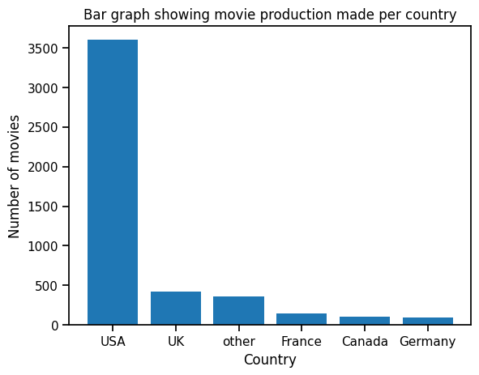

```python
# Group the IMDb dataset by country and calculate the number of movies
countries = data.groupby('Country').size().reset_index(name='number_of_movies')

# Sort the countries by the number of movies in descending order
countries = countries.sort_values('number_of_movies', ascending=False)

# Plotting the bar graph
plt.bar(countries['Country'], countries['number_of_movies'])
plt.xlabel('Country')
plt.ylabel('Number of movies')
plt.title('Bar graph showing movie production made per country')

# Display the plot
plt.show()
```

We can clearly see that the number of movies in the USA dominates the graph, showing the significant contribution and dominance of the global film industry in terms of movie production.

### Relationship between Movie Production and years

By examining the number of movies released each year, we can identify historical trends in the film industry. It allows us to understand the growth or decline in movie production over time. This analysis helps to contextualize the current state of the industry and identify any significant shifts or patterns.

```python
# Group the data by year and calculate the count of movies for each year
year_counts = df.groupby('Year').size().reset_index(name='Number of Movies')

# Sort the dataframe by the year in ascending order
year_counts = year_counts.sort_values('Year')

# Print the resulting dataset
print(year_counts)
```

```
    Year  Number of Movies
0   1927                 1
1   1929                 2
2   1930                 1
3   1932                 1
4   1933                 2
..   ...               ...
83  2012               206
84  2013               214
85  2014               216
86  2015               186
87  2016                85

[88 rows x 2 columns]
```

Therefore, we'll only plot the number of movies produced after 1975

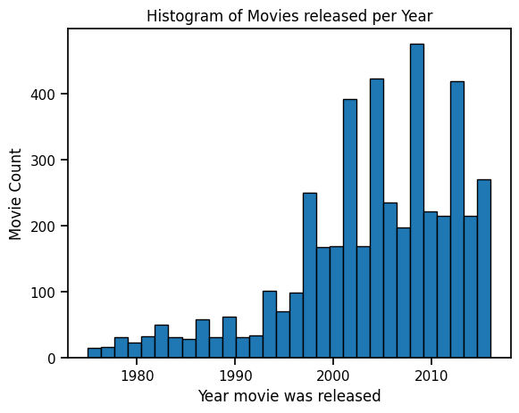

```python
# Filter out records of movies released before 1980
data = data[data['Year'] >= 1975]

# Create a histogram of movies released per year
plt.hist(data['Year'], bins=30, edgecolor='k')
plt.xlabel('Year movie was released')
plt.ylabel('Movie Count')
plt.title('Histogram of Movies released per Year', loc='center')

# Center the plot title
plt.gca().title.set_position([0.5, 1])

# Display the plot
plt.show()
```

### Relation between Genre and Movie Production

Examining the relationship between genre and movie production provides valuable market analysis. By identifying trends and patterns in genre popularity, industry stakeholders can make informed decisions about investments, marketing strategies, and distribution channels. This analysis helps identify potential gaps or opportunities in the market, allowing for better targeting of specific genres to specific audience segments.

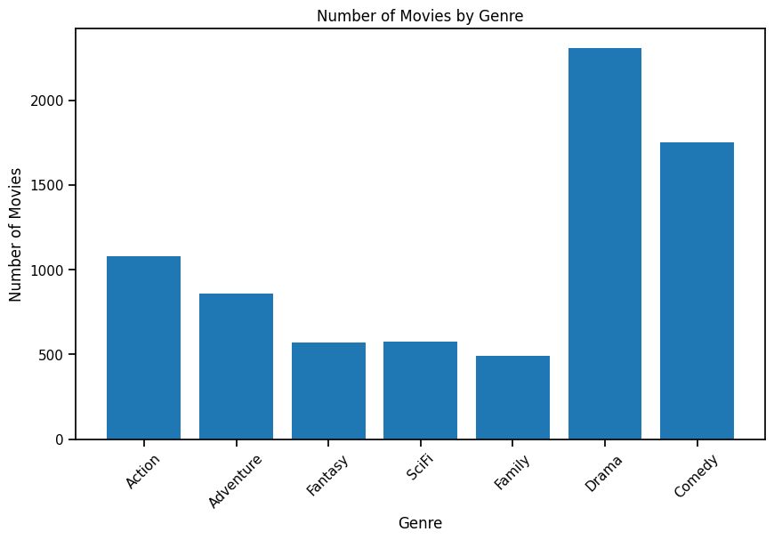

```python
# Count the number of movies for each genre
genre_counts = data[['Action', 'Adventure', 'Fantasy', 'SciFi', 'Family', 'Drama', 'Comedy']].sum()

# Create a bar chart
plt.figure(figsize=(10, 6))
plt.bar(genre_counts.index, genre_counts.values)

# Customize the chart
plt.xlabel('Genre')
plt.ylabel('Number of Movies')
plt.title('Number of Movies by Genre')

# Rotate the x-axis tick labels for better visibility
plt.xticks(rotation=45)

# Display the chart
plt.show()
```

We can see from the graph that there are highest number of Drama movies followed by number of Comedy movies. Showing how more drama and comedy movies are produced compared to other genres.

### Realationship between Gross of a movie and Directors

Understanding the relationship between the gross revenue of a movie and directors helps identify the impact of directorial skills and reputation on the financial success of a film. By analyzing the gross revenue generated by different directors, we can identify successful directors who consistently deliver commercially successful movies. This knowledge is crucial for studios, producers, and investors in determining which directors to collaborate with to maximize box office returns.

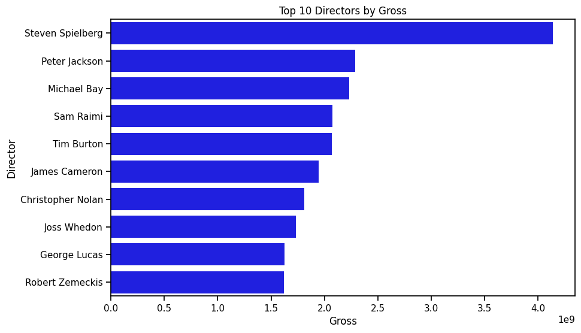

```python
# Prepare the data for plotting
top_directors = data.groupby('Director')['Gross'].sum().nlargest(10).reset_index()

# Plotting
plt.figure(figsize=(10, 6))
sns.barplot(data=top_directors, x='Gross', y='Director', color='blue')

plt.xlabel('Gross')
plt.ylabel('Director')
plt.title('Top 10 Directors by Gross')

# Display the plot
plt.show()
```

We can see from the graph that Steven Spielberg has the highest grossing movies. Steven Spielberg has twice as much gross compared to other directors

### Profit

Profitability is a key indicator of the financial success of a movie. It helps assess the effectiveness of the movie in generating revenue and ultimately determining its commercial viability. Understanding the profitability allows filmmakers, production companies, and investors to evaluate the financial return on their investment and make informed decisions regarding future projects.

```python
#Calculating Profit
data['Profit'] = data['Gross'] - data['Budget']
```

Next, I am plotting a bar chart for the top 10 directors that with most prrofit from movies.

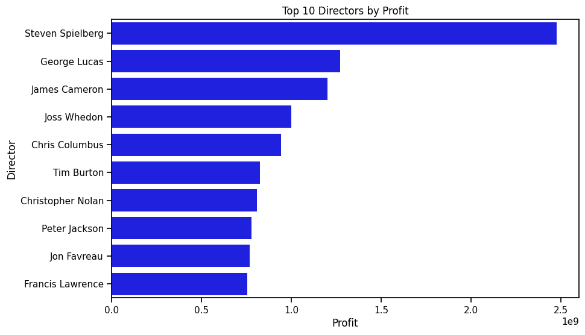

```python
# Prepare the data for plotting
top_directors = data.groupby('Director')['Profit'].sum().nlargest(10).reset_index()

# Plotting
plt.figure(figsize=(10, 6))
sns.barplot(data=top_directors, x='Profit', y='Director', color='blue')

plt.xlabel('Profit')
plt.ylabel('Director')
plt.title('Top 10 Directors by Profit')

# Display the plot
plt.show()
```

From the graph, we can see that Steven Spielberg is the greatest director of all as not noly does he have highest grossing movies but his movies are most profitable. Unlike Peter Jackson who has second highest grossing movies but 8th highest most profitable movies. This show how we can use the EDA to analyse gross revenue and profit generated by different directors, we can identify successful directors who consistently deliver commercially successful movies.

[figure not shown]

```python
# Extract the top 20 profitable movies based on profit
top_movies = data.sort_values('Profit', ascending=False).head(10)

# Plotting
plt.figure(figsize=(15, 10))
sns.scatterplot(data=top_movies, x=top_movies['Budget'] / 1000000, y=top_movies['Profit'] / 1000000, color='blue')
sns.regplot(data=top_movies, x=top_movies['Budget'] / 1000000, y=top_movies['Profit'] / 1000000, color='red', scatter=False)

# Add labels to data points
for i in range(len(top_movies)):
    plt.text(top_movies['Budget'].iloc[i] / 1000000, top_movies['Profit'].iloc[i] / 1000000,
             top_movies['Movie_title'].iloc[i], verticalalignment='center', fontsize=10)

plt.xlabel('Budget $million')
plt.ylabel('Profit $million')
plt.title('Top 20 Profitable Movies')

# Display the plot
plt.show()
```

### Relationship between IMDB Score and Gross

The IMDB score represents the average rating given by viewers, reflecting their perception and evaluation of the movie. By analyzing the relationship between the gross revenue and IMDB score, we can understand how the audience's positive reception, as indicated by higher IMDB scores, translates into financial success. This understanding helps filmmakers and industry professionals gauge the impact of audience feedback on the commercial performance of a movie.

The relationship between the gross revenue and IMDB score provides insights into the marketability of a movie. A higher IMDB score often indicates a more favorable reception among viewers, which can contribute to positive word-of-mouth, increased buzz, and ultimately higher box office revenues. Understanding this relationship helps in assessing the market appeal and potential financial success of a movie based on its audience reception.

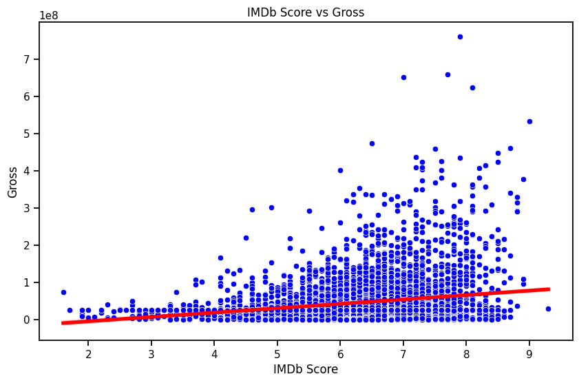

```python
# Create the scatter plot
plt.figure(figsize=(10, 6))
sns.scatterplot(data=data, x='IMDB_Score', y='Gross', color='blue')

# Add the linear regression line
sns.regplot(data=data, x='IMDB_Score', y='Gross', scatter=False, color='red')

# Set the labels and title
plt.xlabel('IMDb Score')
plt.ylabel('Gross')
plt.title('IMDb Score vs Gross')

# Display the plot
plt.show()
```

The graph shows the relationship between the gross revenue of a movie and its IMDB score. The x-axis represents the IMDB scores, while the y-axis represents the gross revenue in a given currency (e.g., dollars). Each data point represents a movie, with its corresponding IMDB score and gross revenue.

From the graph, we observe a positive increasing relationship between the gross revenue and IMDB scores. This means that as the IMDB score increases, the gross revenue tends to increase as well. The overall trend is depicted by the linear regression line, which shows a positive slope.

### Relationship between IMDB score and Total Facebook likes for a movie

Social media platforms like Facebook play a crucial role in movie marketing and promotion. Analyzing the relationship between the IMDB score and total Facebook likes helps assess the effectiveness of marketing campaigns and the ability of positive critical reception to drive audience engagement on social media. This information assists in refining marketing strategies, targeting specific audience segments, and maximizing the reach and impact of promotional efforts.

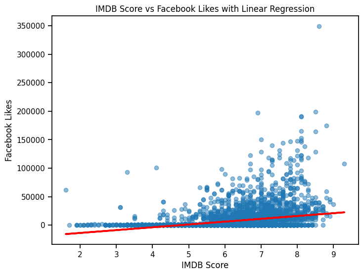

```python
# Subset the data for IMDB score and Facebook likes
imdb_score = data['IMDB_Score']
facebook_likes = data['Facebook_Likes']

# Calculate the linear regression line
slope, intercept = np.polyfit(imdb_score, facebook_likes, 1)
line = slope * imdb_score + intercept

# Create a scatter plot with linear regression line
plt.figure(figsize=(8, 6))
plt.scatter(imdb_score, facebook_likes, alpha=0.5)
plt.plot(imdb_score, line, color='red')
plt.xlabel('IMDB Score')
plt.ylabel('Facebook Likes')
plt.title('IMDB Score vs Facebook Likes with Linear Regression')
plt.show()
```

The graph shows the relationship between the IMDB score and the total number of Facebook likes for a movie. The x-axis represents the IMDB scores, while the y-axis represents the total Facebook likes. Each data point represents a movie, with its corresponding IMDB score and total Facebook likes.

From the graph, we observe a positive increasing relationship between the IMDB score and the total Facebook likes. This means that as the IMDB score increases, the total number of Facebook likes tends to increase as well. The overall trend is depicted by the linear regression line, which shows a positive slope. The linear regression line suggests that movies with higher IMDB scores tend to have a greater number of Facebook likes.

### Relationship between IMDB score and profit

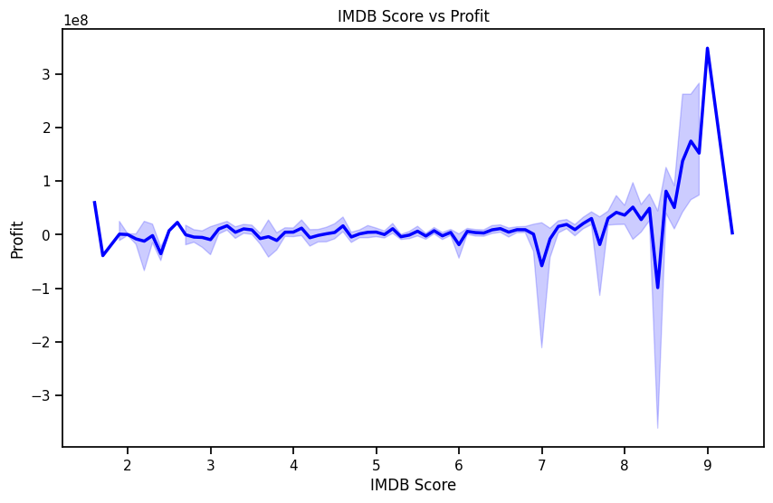

```python
plt.figure(figsize=(10, 6))
sns.lineplot(data=data, x='IMDB_Score', y='Profit', color='blue')
plt.xlabel('IMDB Score')
plt.ylabel('Profit')
plt.title('IMDB Score vs Profit')
plt.show()
```

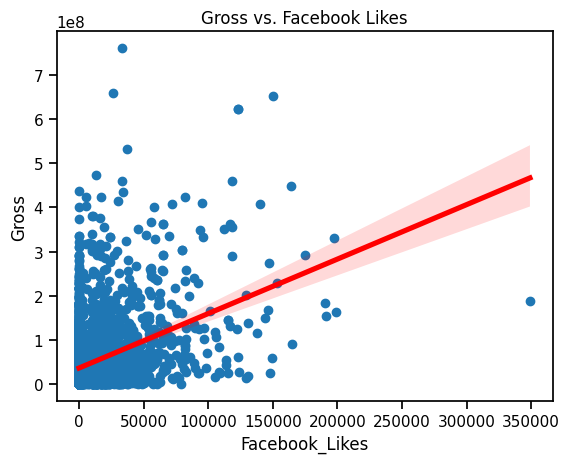

```python
# Step 4: Extract the necessary columns
profit = data['Gross']
fb_likes = data['Facebook_Likes']

# Step 5: Create the graph
plt.scatter(fb_likes, profit)

# Step 6: Customize the graph
plt.xlabel('Facebook Likes')
plt.ylabel('Gross')
plt.title('Gross vs. Facebook Likes')

# Step 7: Perform linear regression
# Add the linear regression line
sns.regplot(data=data, x='Facebook_Likes', y='Gross', scatter=False, color='red')

# Step 9: Display the graph
plt.show()
```

## Hypothesis Testing

In this hypothesis testing, we aim to investigate the proportion of profitable movies in the dataset. The null hypothesis (H0) states that 50% or less of the movies are profitable, while the alternative hypothesis (H1) suggests that more than 50% of the movies are profitable.

To calculate the proportion of profitable movies, we define a logical analogy for profitability: if the profit is greater than 0, the movie is considered profitable; otherwise, it is considered unprofitable.

By conducting hypothesis testing, we can evaluate the evidence and determine whether there is sufficient support to reject the null hypothesis in favor of the alternative hypothesis.

```python
# Add the 'profitable' column
data['Profitable'] = np.where(data['Profit'] > 0, True, False)

# Calculate the number of profitable and unprofitable movies
profitable_count = data['Profitable'].sum()
total_count = len(data)

# Calculating p_hat (proportion of profitable movies)
p_hat = profitable_count / total_count

# Set the significance level
alpha = 0.05

# Perform the hypothesis test
z_stat, p_value = proportions_ztest(profitable_count, total_count, value=0.5)

# Evaluate the p-value
if p_value <= alpha:
    print(p_value)
    print(p_hat)
    print("Reject the null hypothesis")
else:
    print(p_value)
    print(p_hat)
    print("Fail to reject the null hypothesis")
```

```
4.642087620790794e-13
0.5533553355335533
Reject the null hypothesis
```

The result of the hypothesis testing suggests that we have sufficient evidence to reject the null hypothesis, which stated that 50% or less of the movies are profitable.

Based on the dataset, the proportion of profitable movies (p_hat) is calculated to be approximately 0.5534, indicating that more than 55% of the movies are profitable.

The hypothesis test was performed using a significance level (alpha) of 0.05. The resulting p-value is extremely small (approximately 4.64e-13), which is significantly smaller than the significance level. Therefore, we reject the null hypothesis in favor of the alternative hypothesis, which states that more than 50% of the movies are profitable.

This implies that the dataset provides strong evidence that a significant portion of movies are profitable, contradicting the assumption that profitability is limited to 50% or less of the movies. The findings support the hypothesis that movies can be financially successful, even if they have lower budgets, as seen in the previous analysis of profits vs. budgets.

# Linear Regression Model

In this analysis, we aim to explore the relationship between the IMDb score and the year of release for movies. To investigate this relationship, we will employ a linear regression model. The objective is to determine if there is a significant relationship between the IMDb score and the year of release.

The null hypothesis (H0) in this case assumes that there is no relationship between the IMDb score and the year of release. In other words, the IMDb score is not influenced by the year in which a movie is released.

By fitting the linear regression model and conducting appropriate statistical tests, we can evaluate whether there is evidence to reject the null hypothesis and conclude that a relationship exists between the IMDb score and the year of release for movies.

```python
# Filter the data for movies released from 2000 to 2017
filtered_data = data[(data['Year'] >= 1990) & (data['Year'] <= 2017)]

# Prepare the data for regression analysis
X = filtered_data['Year']
y = filtered_data['IMDB_Score']

# Add a constant term to the predictor variable
X = sm.add_constant(X)

# Fit the linear regression model
model = sm.OLS(y, X).fit()

# Print the summary of the model
print(model.summary())
```

```
                            OLS Regression Results
==============================================================================
Dep. Variable:             IMDB_Score   R-squared:                       0.005
Model:                            OLS   Adj. R-squared:                  0.005
Method:                 Least Squares   F-statistic:                     22.37
Date:                Sat, 13 May 2023   Prob (F-statistic):           2.33e-06
Time:                        09:12:48   Log-Likelihood:                -6276.1
No. Observations:                4192   AIC:                         1.256e+04
Df Residuals:                    4190   BIC:                         1.257e+04
Df Model:                           1
Covariance Type:            nonrobust
==============================================================================
                 coef    std err          t      P>|t|      [0.025      0.975]
------------------------------------------------------------------------------
const         31.5725      5.330      5.923      0.000      21.122      42.023
Year          -0.0126      0.003     -4.729      0.000      -0.018      -0.007
==============================================================================
Omnibus:                      440.861   Durbin-Watson:                   1.887
Prob(Omnibus):                  0.000   Jarque-Bera (JB):              653.399
Skew:                          -0.791   Prob(JB):                    1.31e-142
Kurtosis:                       4.114   Cond. No.                     6.40e+05
==============================================================================

Notes:
[1] Standard Errors assume that the covariance matrix of the errors is correctly specified.
[2] The condition number is large, 6.4e+05. This might indicate that there are
strong multicollinearity or other numerical problems.
```

The linear regression analysis between the IMDb score and the year of release for movies from 1990 to 2017 reveals the following results:

R-squared: The R-squared value of 0.005 indicates that approximately 0.5% of the variability in the IMDb score can be explained by the year of release. This suggests that the year of release has a very weak, but statistically significant, association with the IMDb score.

Year coefficient: The coefficient for the predictor variable "Year" is -0.0126. This means that, on average, there is a small decrease (-0.0126) in the IMDb score per unit increase in the year of release. The coefficient is statistically significant, as indicated by the p-value (P>|t|) of 0.

Overall, the linear regression model shows a very weak negative relationship between the IMDb score and the year of release for movies from 1990 to 2017. The R-squared value suggests that there are other factors beyond the year of release that have a more substantial influence on the IMDb score. However, the statistically significant coefficient for the "Year" variable indicates that there is a small but meaningful relationship between the two.

Therefore, based on the analysis, we can conclude that the year of release has a weak negative association with the IMDb score for movies released from 1990 to 2017.

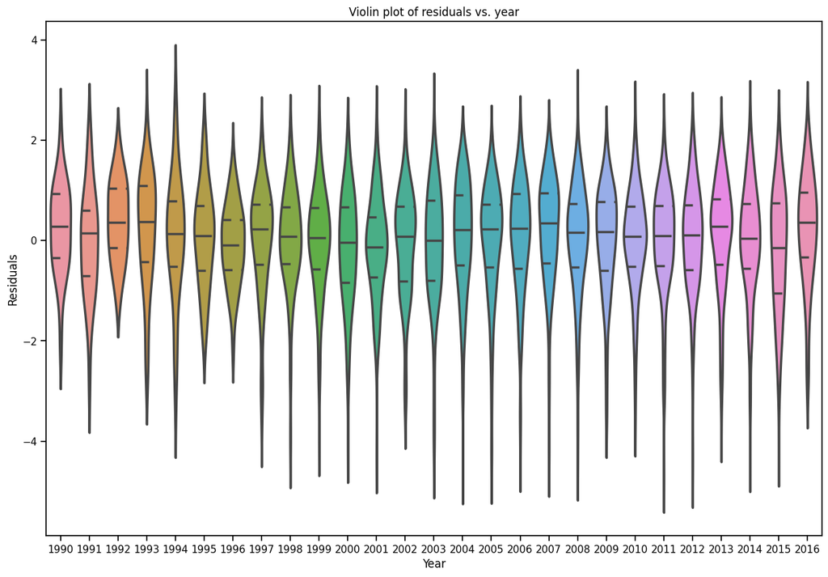

```python
# Obtain the residuals and year data
residuals = model.resid
years = filtered_data['Year']

# Create a DataFrame combining residuals and years
data1 = pd.DataFrame({'Residuals': residuals, 'Year': years})

# Create a violin plot of residuals vs. year
plt.figure(figsize=(15, 10))
sns.violinplot(data=data1, x='Year', y='Residuals', inner='quartile')
plt.title("Violin plot of residuals vs. year")
plt.xlabel("Year")
plt.ylabel("Residuals")
plt.show()
```

The violin plot displays the distribution of the residuals, which are the differences between the predicted IMDb scores and the actual IMDb scores, across different years. Each vertical "violin" represents a specific year, and the width of the violin corresponds to the density of residuals for that year.

The height and shape of the violin at each year indicate the density of residuals for that particular year. A taller and wider violin indicates a higher density of residuals, suggesting more variability in the IMDb scores for that year. Conversely, a shorter and narrower violin represents a lower density of residuals and less variability in the IMDb scores.

### Plotting residuals vs fitted values

To further assess the linearity assumption of the linear regression model, we can create a scatterplot of the residuals (difference between actual and predicted IMDb scores) versus the fitted values (predicted IMDb scores). This plot allows us to examine whether there are any clear patterns or nonlinear relationships between the outcome (IMDb score) and the predictor (year of release).

By plotting the residuals against the fitted values, we can visually inspect if there are any systematic patterns in the distribution of residuals

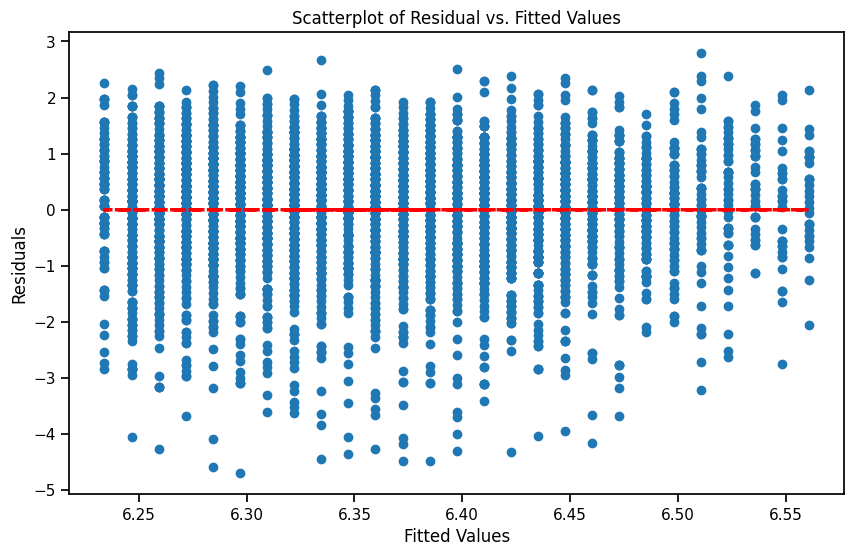

```python
# Obtain the fitted values from the model
fitted_values = model.fittedvalues

# Create a scatterplot of residual vs. fitted values
plt.figure(figsize=(10, 6))
plt.scatter(fitted_values, residuals)
plt.plot(fitted_values, [0] * len(fitted_values), color='red', linestyle='--')
plt.title("Scatterplot of Residual vs. Fitted Values")
plt.xlabel("Fitted Values")
plt.ylabel("Residuals")
plt.show()
```

## Data Prediction: Comparison of Classification Models

In this section, we aim to predict the binned IMDb scores of movies using various classification models. We have performed data preparation steps to preprocess the dataset, including removing irrelevant columns, handling correlated variables, and encoding categorical features. The prepared dataset has been split into training and test sets for model evaluation.

### Data Preparation for the models

We begin by preparing the dataset for the classification models. This involves several steps to ensure that the data is in a suitable format and contains relevant features for the prediction task.

```python
columns_to_drop = ['color', 'movie_imdb_link', 'Movie_title', 'plot_keywords','plot_keywords']
data2 = df.drop(columns_to_drop, axis=1)
data2.head()
```

|  | Director | num_critic_for_reviews | duration | director_facebook_likes | actor_3_facebook_likes | Actor_2 | actor_1_facebook_likes | Gross | Genres | Actor_1 | ... | num_user_for_reviews | Language | Country | Content_Rating | Budget | Year | actor_2_facebook_likes | IMDB_Score | aspect_ratio | Facebook_Likes |
| --- | --- | --- | --- | --- | --- | --- | --- | --- | --- | --- | --- | --- | --- | --- | --- | --- | --- | --- | --- | --- | --- |
| 0 | James Cameron | 723.0 | 178.0 | 0.0 | 855.0 | Joel David Moore | 1000.0 | 760505847.0 | Action\|Adventure\|Fantasy\|Sci-Fi | CCH Pounder | ... | 3054.0 | English | USA | PG-13 | 237000000.0 | 2009 | 936.0 | 7.9 | 1.78 | 33000 |
| 1 | Gore Verbinski | 302.0 | 169.0 | 563.0 | 1000.0 | Orlando Bloom | 40000.0 | 309404152.0 | Action\|Adventure\|Fantasy | Johnny Depp | ... | 1238.0 | English | USA | PG-13 | 300000000.0 | 2007 | 5000.0 | 7.1 | 2.35 | 0 |
| 2 | Sam Mendes | 602.0 | 148.0 | 0.0 | 161.0 | Rory Kinnear | 11000.0 | 200074175.0 | Action\|Adventure\|Thriller | Christoph Waltz | ... | 994.0 | English | UK | PG-13 | 245000000.0 | 2015 | 393.0 | 6.8 | 2.35 | 85000 |
| 3 | Christopher Nolan | 813.0 | 164.0 | 22000.0 | 23000.0 | Christian Bale | 27000.0 | 448130642.0 | Action\|Thriller | Tom Hardy | ... | 2701.0 | English | USA | PG-13 | 250000000.0 | 2012 | 23000.0 | 8.5 | 2.35 | 164000 |
| 5 | Andrew Stanton | 462.0 | 132.0 | 475.0 | 530.0 | Samantha Morton | 640.0 | 73058679.0 | Action\|Adventure\|Sci-Fi | Daryl Sabara | ... | 738.0 | English | USA | PG-13 | 263700000.0 | 2012 | 632.0 | 6.6 | 2.35 | 24000 |

5 rows × 24 columns

To handle correlated variables, we analyze the correlation matrix of the remaining features using a heatmap. We identify variables that exhibit high correlation and modify them accordingly.

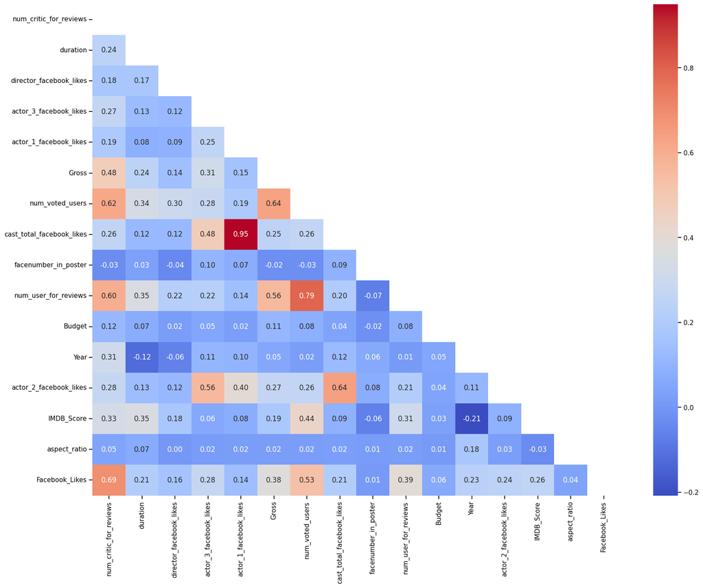

```python
corr = data2.corr()

plt.figure(figsize=(20, 15))
sns.set_context("notebook", font_scale=1.0, rc={"lines.linewidth": 2.5})

# Create a mask to display only the lower triangle of the heatmap
mask = np.triu(np.ones_like(corr, dtype=bool))

# Plot the correlation heatmap
sns.heatmap(corr, mask=mask, annot=True, fmt='.2f', cmap='coolwarm')

# Rotate the x-axis tick labels by 90 degrees
plt.xticks(rotation=90)


plt.show()
```

To handle correlated variables, we analyze the correlation matrix of the remaining features using a heatmap. We identify variables that exhibit high correlation and modify them accordingly.

For example, we can see that the cast_total_facebook_likes and actor_1_facebook_like are highly correlated (0.95 on the heatmap) to each other. We combine the Facebook likes of actor 2 and actor 3 into a single variable called 'Other_actor_facebook_likes'. We also create a new variable called 'critic_review_ratio' by taking the ratio of 'num_critic_for_reviews' to 'num_user_for_reviews'. These modifications help reduce redundancy and improve the independence of the variables.

```python
#Adding the facebook likes of actor 2 and actor 3 together
data2['Other_actor_facebbok_likes'] = data2["actor_2_facebook_likes"] + data2['actor_3_facebook_likes']
data2.drop('actor_2_facebook_likes',axis=1,inplace=True)
data2.drop('actor_3_facebook_likes',axis=1,inplace=True)
data2.drop('cast_total_facebook_likes',axis=1,inplace=True)
data2['critic_review_ratio']=data2['num_critic_for_reviews']/data2['num_user_for_reviews']
data2.drop('num_critic_for_reviews',axis=1,inplace=True)
data2.drop('num_user_for_reviews',axis=1,inplace=True)
```

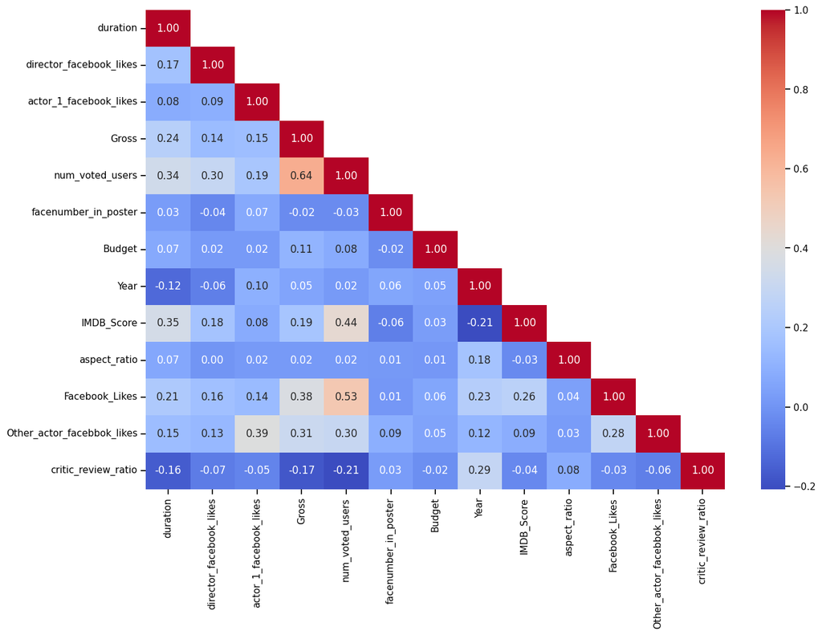

```python
corr = data2.corr()

plt.figure(figsize=(15, 10))
sns.set_context("notebook", font_scale=1.0, rc={"lines.linewidth": 2.5})

# Create a mask to display only the lower triangle of the heatmap
mask = np.triu(corr, k=1)

# Plot the correlation heatmap
sns.heatmap(corr, mask=mask, annot=True, fmt='.2f', cmap='coolwarm',
            xticklabels=True, yticklabels=True)

# Rotate the x-axis tick labels by 90 degrees
plt.xticks(rotation=90)



plt.show()
```

Furthermore, we categorize the IMDb scores into four bins representing different quality levels: bad, average, good, and excellent movies. This allows us to simplify the classification problem and map the IMDb scores into discrete classes.

```python
data2["imdb_binned_score"]=pd.cut(data2['IMDB_Score'], bins=[0,4,6,8,10], right=True, labels=False)+1
data2.drop('IMDB_Score',axis=1,inplace=True)
data2 = pd.get_dummies(data = data2, columns = ['Country'] , prefix = ['Country'] , drop_first = True)
data2 = pd.get_dummies(data = data2, columns = ['Content_Rating'] , prefix = ['Content_Rating'] , drop_first = True)
```

By performing these data preparation steps, we ensure that the dataset is appropriately structured, irrelevant columns are removed, correlated variables are modified, and categorical variables are encoded. This sets the stage for training and evaluating the classification models on the prepared dataset.

## Spitting the data (Testing and Training set)

In this section, we split the prepared dataset into two subsets: training data and test data. This is a crucial step in evaluating the performance and generalization ability of the classification models.

The purpose of splitting the data is to have a portion of the dataset that is not used during model training, which can later be used to evaluate the model's performance on unseen data. The training data is used to train the models, allowing them to learn patterns and relationships in the data, while the test data serves as a benchmark to assess how well the models generalize to new observations.

```python
X=pd.DataFrame(columns=['duration','director_facebook_likes','actor_1_facebook_likes','gross','num_voted_users','facenumber_in_poster','budget','title_year','aspect_ratio','movie_facebook_likes','Other_actor_facebbok_likes','critic_review_ratio','country_USA','country_other','content_rating_G','content_rating_GP','content_rating_M','content_rating_NC-17','content_rating_Not Rated','content_rating_PG','content_rating_PG-13','content_rating_Passed','content_rating_R','content_rating_TV-14','content_rating_TV-G','content_rating_TV-PG','content_rating_Unrated','content_rating_X'],data=data2)
y=pd.DataFrame(columns=['imdb_binned_score'],data=data2)
from sklearn.model_selection import train_test_split
X_train, X_test, y_train, y_test=train_test_split(X,y,test_size=0.3,random_state=100)
```

The commonly used approach for splitting the data is the train-test split, where a certain percentage of the data is allocated for training and the remaining percentage is reserved for testing. In our case, we allocate 70% of the data for training and 30% for testing, as specified by the test_size=0.3 parameter in the train_test_split function.

By splitting the data, we can evaluate the performance metrics, such as accuracy, precision, recall, and F1-score, on the test data to assess how well the models are able to classify the IMDb scores of movies. This evaluation provides insights into the models' ability to generalize to unseen data and helps in selecting the best-performing model for our prediction task.

## KNN Clasifier

We transform the test data (X_test) using the already fitted imputer. The transform method fills in the missing values in X_test with the respective means learned from the training data, producing X_test_imputed.

We create a KNN classifier with n_neighbors set to 22 and fit it on the imputed training data (X_train_imputed) and corresponding labels (y_train). The classifier learns the patterns and relationships in the data.

We then predict on the imputed test data (X_test_imputed) using the fitted KNN classifier. The predicted values are stored in knnpred. We calculate the confusion matrix using metrics.confusion_matrix to evaluate the performance of the classifier. The confusion matrix shows the number of true positives, true negatives, false positives, and false negatives for each class. Additionally, we calculate the accuracy score using metrics.accuracy_score, which provides the overall accuracy of the classifier.

```python
# Create an instance of the SimpleImputer with desired strategy
imputer = SimpleImputer(strategy='mean')

# Fit the imputer on the training data and transform it
X_train_imputed = imputer.fit_transform(X_train)

# Transform the test data using the fitted imputer
X_test_imputed = imputer.transform(X_test)

# Create and fit the KNN classifier using the imputed data
knn = KNeighborsClassifier(n_neighbors=22)
knn.fit(X_train_imputed, np.ravel(y_train, order='C'))

# Predict on the test data and evaluate the performance
knnpred = knn.predict(X_test_imputed)
cnf_matrix = metrics.confusion_matrix(y_test, knnpred)
print(cnf_matrix)
print("Accuracy:", metrics.accuracy_score(y_test, knnpred))
```

```
[[  0  18  35   0]
 [  0 105 298   0]
 [  0 117 782   4]
 [  0   2  41  20]]
Accuracy: 0.6378340365682138
```

Based on the confusion matrix, it can be observed that the classifier had challenges distinguishing between classes 2 and 3, as indicated by the relatively high number of false positive and false negative predictions for these classes.

## Support Vector Classifier (SVC)

We utilize the SVC algorithm for classification. We transform both the training and test data (X_train and X_test) using the fitted imputer. This replaces any missing values in the datasets with the corresponding mean values learned from the training data. The transformed data is stored in X_train_imputed and X_test_imputed, respectively.

We create an instance of SVC with the desired kernel, in this case, 'sigmoid'. The SVC model will be trained using the imputed training data.

We fit the SVC model on the imputed training data (X_train_imputed) and the corresponding labels (y_train) using the fit method. The model learns the patterns and relationships in the data.

Next, we use the trained model to predict on the imputed test data (X_test_imputed) and store the predicted values in svcpred.

We calculate the confusion matrix using metrics.confusion_matrix to evaluate the performance of the classifier. The confusion matrix provides insights into the number of true positives, true negatives, false positives, and false negatives for each class.

Finally, we calculate the accuracy score using metrics.accuracy_score, which gives the overall accuracy of the classifier in predicting the correct class labels.

```python
#SVC

# Create an instance of SimpleImputer to handle missing values
imputer = SimpleImputer(strategy='mean')

# Fit the imputer on X_train to learn the mean values for imputation
imputer.fit(X_train)

# Transform X_train and X_test to replace the missing values with the learned mean values
X_train_imputed = imputer.transform(X_train)
X_test_imputed = imputer.transform(X_test)

# Create an instance of SVC with the desired kernel
svc = SVC(kernel='sigmoid')

# Fit the SVC model on the imputed training data
svc.fit(X_train_imputed, np.ravel(y_train, order='C'))

# Predict on the imputed test data
svcpred = svc.predict(X_test_imputed)

# Calculate and print the confusion matrix
cnf_matrix = metrics.confusion_matrix(y_test, svcpred)
print(cnf_matrix)

# Calculate and print the accuracy score
accuracy = metrics.accuracy_score(y_test, svcpred)
print("Accuracy:", accuracy)
```

```
[[  0  30  23   0]
 [  0 123 280   0]
 [ 13 186 704   0]
 [ 25   3  35   0]]
Accuracy: 0.5815752461322081
```

## Random Forest Classifier

We create an instance of RandomForestClassifier from sklearn.ensemble with the desired number of estimators (200 in this case). RandomForestClassifier is an ensemble algorithm that combines multiple decision trees to make predictions.It can handle both classification and regression tasks and is known for its robustness and ability to handle complex relationships in the data. We fit the RandomForestClassifier model on the imputed training data (X_train_imputed) and the corresponding target labels (y_train). The model learns the patterns and relationships in the data to make predictions. Next, we transform the test data (X_test) using the same imputer to replace missing values with the learned mean values. We then use the trained RandomForestClassifier to predict the labels for the imputed test data.

```python
# Create an instance of SimpleImputer to handle missing values
imputer = SimpleImputer(strategy='mean')

# Fit the imputer on X_train to learn the mean values for imputation
imputer.fit(X_train)

# Transform X_train to replace the missing values with the learned mean values
X_train_imputed = imputer.transform(X_train)

# Create an instance of RandomForestClassifier with the desired number of estimators
rfc = RandomForestClassifier(n_estimators=200)  # criterion = 'entropy' or 'gini'

# Fit the RandomForestClassifier model on the imputed training data
rfc.fit(X_train_imputed, np.ravel(y_train, order='C'))

# Transform X_test to replace the missing values with the learned mean values
X_test_imputed = imputer.transform(X_test)

# Predict on the imputed test data
rfcpred = rfc.predict(X_test_imputed)

# Calculate and print the confusion matrix
cnf_matrix = metrics.confusion_matrix(y_test, rfcpred)
print(cnf_matrix)

# Calculate and print the accuracy score
accuracy = metrics.accuracy_score(y_test, rfcpred)
print("Accuracy:", accuracy)
```

```
[[  0  29  24   0]
 [  2 160 241   0]
 [  0 113 784   6]
 [  0   0  39  24]]
Accuracy: 0.680731364275668
```

The obtained confusion matrix shows the number of correctly classified instances (true positives) and misclassifications (false positives and false negatives) across different classes. The accuracy of 68.07% indicates that the classifier correctly predicts the class labels for approximately 68.07% of the instances in the test data.

**Random Forest Classifier:** Accuracy: 0.680731364275668 Random Forest Classifier achieved an accuracy of approximately 68.07%. The imputation of missing values using mean imputation was performed. Random Forest Classifier outperformed the other models in terms of accuracy.

## Conclusion

### Recap:

The purpose of this project was to analyze a movie dataset and explore various factors such as the number of movies, year of release, budget, profit, gross, language, genres, directors, and more. Through exploratory data analysis (EDA) and data prediction using classification models, we aimed to gain insights into the movie industry and understand the relationships between different variables.

### Future Scope of data analysis:

Looking ahead, there are several avenues for future analysis. Firstly, incorporating additional variables such as actors, production companies, and release regions could provide deeper insights into the movie industry. Furthermore, fine-tuning the hyperparameters of the classification models and exploring other evaluation metrics like precision, recall, and F1-score would enhance the model assessment. Additionally, conducting sentiment analysis on user reviews or utilizing natural language processing techniques could provide a more comprehensive understanding of the factors influencing movie success.

# Limitations:

This project has certain limitations. The dataset used may not represent the entire movie industry, as it is based on a specific dataset with its own biases and limitations. Additionally, the accuracy of the classification models may be influenced by the quality and representativeness of the features used for prediction. Moreover, the conclusions drawn are based on the data available up until the project's knowledge cutoff in 2017.